# Retrogradacja Marsa a konflikty

Tomasz Stąpor

29 September 2014

Test statystyczny sprawdzający hipotezę astrologiczną głoszącą, że retrogradujący Mars sprzyja konfliktom. Przebadałem 159 początków konfliktów militarnych i sprawdziłem, czy w tych dniach Mars znajdował się w retrogradacji częściej, niż można było się spodziewać na podstawie wyliczeń astronomiczno-statystycznych. Badanie nie potwierdziło prawdziwości hipotezy, że retrogradujący Mars pojawia się częściej podczas powstawania konfliktów militarnych.

## Baza danych

Badanie oparłem o dane na temat konfliktów militarnych w latach 1946-2013, jakie znalazłem w [UCDP/PRIO Armed Conflict Dataset v.4-2014, 1946 – 2013](http://www.pcr.uu.se/research/ucdp/datasets/ucdp_prio_armed_conflict_dataset/). Baza pochodzi z 2014 roku i jest wydawana przez dwie skandynawskie organizacjie (UCDP i PRIO) zajmujące się badaniem konfliktów na świecie. Dokładny opis bazy danych wraz z wyjaśnieniem poszczególnych zmiennych znajduje się w [Codebook](http://www.pcr.uu.se/digitalAssets/124/124920_1codebook_ucdp_prio-armed-conflict-dataset-v4_2014.pdf).

[output not shown]

[output cut: 2313 more lines]

Podstawową jednostką w bazie jest konflikt militarny, który posiada unikalny ID. W sumie są odnotowane 254 konfilkty militarne, których trwanie w kolejnych latach odwzorowane jest w 2134 rekordach. Rekord to kolejny rok, w którym odnotowano conajmniej 25 ofiar śmiertelnych danego konfliktu. Dla lepszego zobrazowania tej struktury posłużę się fragmentem z bazy:

[output not shown]

[output cut: 2313 more lines]

Konflikt o ID 1-78 to konflikt w Etiopii, którego epizody pochłaniające conajmniej 25 ofiar śmiertelnych rozegrały się w latach 1964, 1965, 1966, […], [1991]. Pierwsza ofiara śmiertelna tego konfliktu pojawiła się — wg *StartDate* 30.09.1961. Kolumna *StartPrec* pokazuje dokładność tej daty.

### Struktura bazy danych

```
##     ConflictId Location Year  StartDate StartPrec
## 1          1-1  Bolivia 1946 1946-06-30         4
## 2          1-1  Bolivia 1952 1946-06-30         4
## 3          1-1  Bolivia 1967 1946-06-30         4
## 807       1-78 Ethiopia 1964 1961-09-30         3
## 808       1-78 Ethiopia 1965 1961-09-30         3
## 809       1-78 Ethiopia 1966 1961-09-30         3
```

### Ilość konfliktów militarnych w latach 1946-2013:

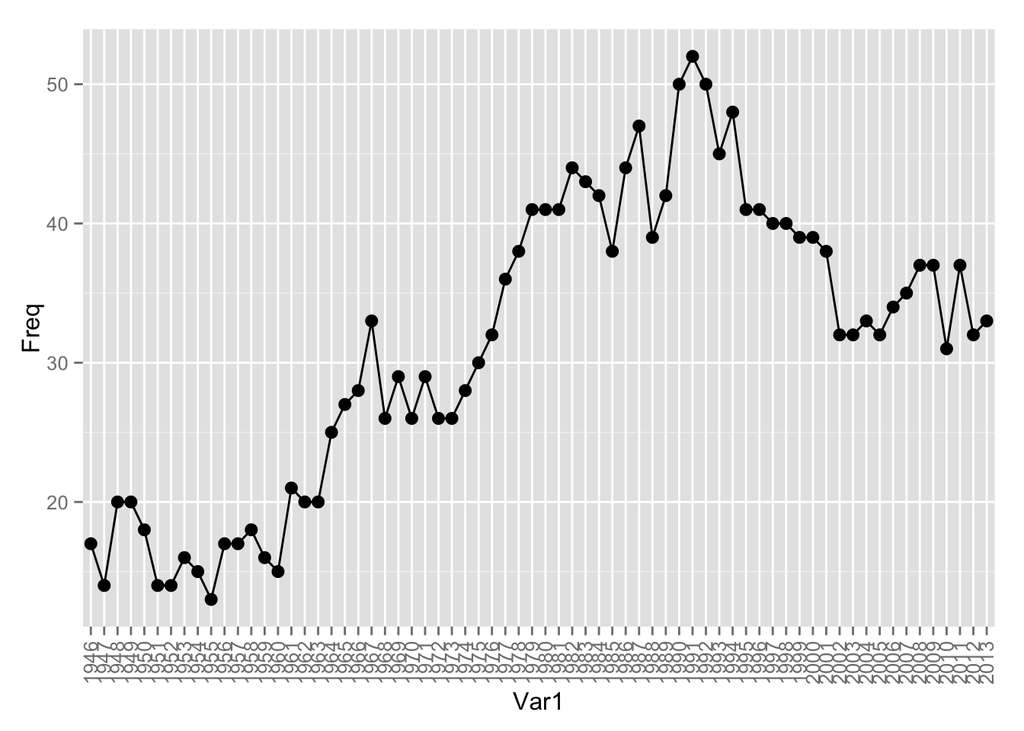

Na wykresie widać, że najwięcej konfliktów, 52 było w 1991 roku. Dla przykładu pik z 1967 roku, wskazuje na 33 konflikty.

Tego typu dane nie nadają się do sprawdzenia hipotezy o retrogradującym Marsie. Czas jego retrogradacji wynosi około 72 dni i dlatego posługiwanie się danymi, których dokładność wynosi 1 rok nie ma tutaj zastosowania.

### Konflikty ze dokładną datą początku

Do dalszego badania zostały wybrane jedynie te rekordy, których StartPrec jest równe 1, a więc te, do których nie ma wątpliwości, że data w kolumnie StartDate jest dokładna. Pierwsze 6 z 1163 rekordów:

```
##     ConflictId                Location Year  StartDate StartPrec
## 41         1-7                    Iran 1946 1945-11-19         1
## 115       1-15        France, Thailand 1946 1946-05-07         1
## 116       1-16 Albania, United Kingdom 1946 1946-10-22         1
## 117       1-17 Vietnam (North Vietnam) 1946 1946-11-20         1
## 118       1-17 Vietnam (North Vietnam) 1947 1946-11-20         1
## 119       1-17 Vietnam (North Vietnam) 1948 1946-11-20         1
```

Następnie dokonałem zliczenia wszystkich dat występujących w kolumnie StartDate:

```
##         Var1 Freq
## 1 1945-11-19    1
## 2 1946-05-07    1
## 3 1946-10-22    1
## 4 1946-11-20    9
## 5 1947-02-28    1
## 6 1947-03-29    1
```

```
## [1] 159
```

## Test statystyczy

1. Wartość oczekiwana: Mars w retro przebywa 72 dni na 780 dni = 72/780 = 0,0923 = 9,23% czasu;
2. Wynik badania: 12 na 159 = 0,0755, czyli 7,6%

```r
prop.test(x=12, n=159, p = 72/780, alternative = "greater", conf.level=0.95, correct=FALSE)
```

```
##
##  1-sample proportions test without continuity correction
##
## data:  12 out of 159, null probability 72/780
## X-squared = 0.5379, df = 1, p-value = 0.7683
## alternative hypothesis: true p is greater than 0.09231
## 95 percent confidence interval:
##  0.04768 1.00000
## sample estimates:
##       p
## 0.07547
```

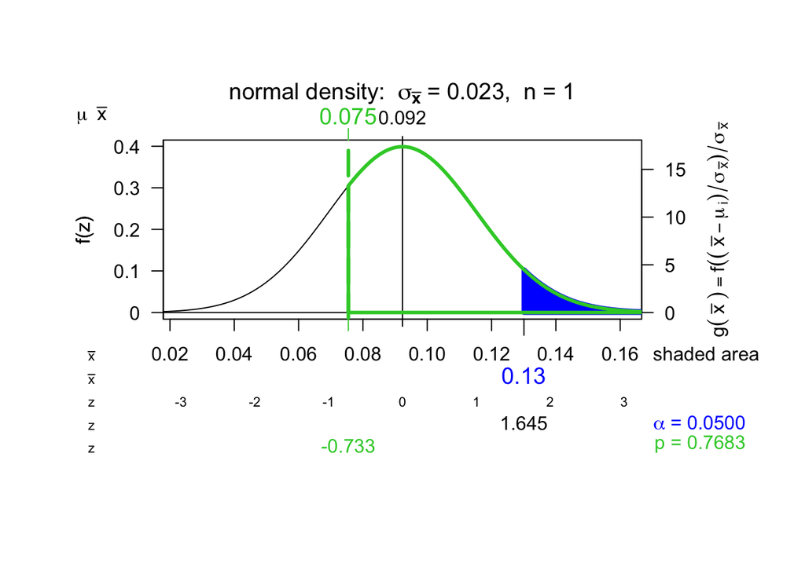